# 오지환 선수 논란이 우리에게 알려주는 것

권용범

2018년 11월 2일

## 데이터에 흥미를 가지게 된 이유

1. 아시안게임 선수 발표 이후 오지환 선수에 대한 논란은 사회적으로 크게 주목을 받았습니다. 하지만 대부분의 논의들은 소모적이고 합의점을 내릴 수 있는 수준의 논의는 형성 되지 못했습니다. 야구를 사랑하는 저로써 어떻게 하면 조금더 생산적인 논의를 할 수 있을까 고민을 하게 되었습니다. 이렇게 데이터에 흥미를 가지게 되었습니다.
2. 데이터와 관련된 배경 이론 = 제가 이번 분석에 주로 사용하게 된 column에 대해서 간략하게 설명을 드리겠습니다. 타율, BA(Batting Average)는 안타/타석입니다. AB(At Bat), 타석은 타자가 타석에 들어서서 타격을 완료한 횟수를 말합니다. 볼넷, 희생번트, 포수 타격 방해등은 타수에 포함되지 않습니다. 타점은 타자의 플레이로 주자가 홈베이스에 들어와 득점했을 때 플레이를 만든 타자에게 주어지는 점수를 말합니다. 그다음 출루율(OBP)는 단어가 말해주듯이 얼마나 많이 출루를 했는지를 보여주는 수치입니다. 마지막으로 SLG은 타율에서 발생하는 저평가 문제, 즉 모든 안타를 똑같은 가치로 바라보는 문제를 해결하기 위해서 홈런, 2루타, 3루타, 안타 각각 다른 가중치를 곱해서 산출한 수치입니다.
3. 데이터를 통해 알고자 하는 내용 = 선동렬 감독은 “유격수 부분에는 김하성 선수가 가정 성적이 좋았었고 오지환이 (엔트리 발표일인 6월 11일 기준) 유격수에서 두 번째로 좋았습니다.“ 그럼 정말로 오지환 선수가 유격수에서 두 번째로 우수한 선수였는가?
4. 데이터와 관련하여 특별한 가설이 있나요? 있다면 그런 가설을 가지된 배경 이론이나 개인적인 경험은 무엇인가요? = 세이버메트릭스(Sabermetrics), Sabermetrics is the scientific and objective analysis of baseball. 세이버메트릭스란 야구에 대한 과학적이고 객관적인 평가이다. 타율, 타점, 홈런 전통적인 기록들이 선수를 잘 평가하는 가? 그렇지 않다면 그 선수의 능력치를 잘 표현해주는 기록, 또는 수치를 통해서 조금 더 야구라는 게임을 객관적으로 평가할 수 있는 방법택하고 있는 방법입니다.

```r
library("ggplot2")
library("lattice")
library("readxl")
library("dplyr")
```

## 데이터 불러오기

```r
Player <- read_excel("Playerstat.xlsx")
Team <- read_excel("Teamstat.xlsx")
Defense <- read_excel("Defense.xlsx")

Player <- rename(Player,
                 double = '2B',
                 Triple = '3B')

Player <- Player %>%
  mutate(OBP = (H+BB+HBP)/(AB+BB+HBP+SF),
         TB = H+2*double+3*Triple+4*HR,
         SLG = TB/AB,
         RC = H+BB*TB/AB+BB)

Team <- Team %>%
  mutate(RC = H+BB*TB/AB+BB)

Player_new <- left_join(Player, Defense, by = "Player")
```

## Summarize function

```r
summary(Player_new)
```

```
##     Player               AVG               AB              R
##  Length:10          Min.   :0.1450   Min.   : 69.0   Min.   : 7.00
##  Class :character   1st Qu.:0.2522   1st Qu.:163.2   1st Qu.:21.75
##  Mode  :character   Median :0.2780   Median :191.0   Median :27.50
##                     Mean   :0.2634   Mean   :182.7   Mean   :26.70
##                     3rd Qu.:0.2898   3rd Qu.:210.2   3rd Qu.:31.25
##                     Max.   :0.3230   Max.   :247.0   Max.   :44.00
##        H            double          Triple           HR
##  Min.   :10.0   Min.   : 3.00   Min.   :0.00   Min.   :0.0
##  1st Qu.:45.5   1st Qu.: 5.50   1st Qu.:0.00   1st Qu.:1.5
##  Median :50.0   Median : 8.50   Median :0.50   Median :4.5
##  Mean   :49.9   Mean   : 8.40   Mean   :0.90   Mean   :4.1
##  3rd Qu.:57.0   3rd Qu.:10.75   3rd Qu.:1.75   3rd Qu.:6.0
##  Max.   :74.0   Max.   :13.00   Max.   :3.00   Max.   :9.0
##       RBI             SB            SC            BB             HBP
##  Min.   : 7.0   Min.   :1.0   Min.   :0.0   Min.   : 8.00   Min.   :1.00
##  1st Qu.:15.0   1st Qu.:2.0   1st Qu.:0.5   1st Qu.: 9.50   1st Qu.:1.25
##  Median :26.0   Median :3.5   Median :3.0   Median :13.50   Median :2.50
##  Mean   :22.9   Mean   :3.7   Mean   :3.1   Mean   :14.80   Mean   :2.80
##  3rd Qu.:29.0   3rd Qu.:5.5   3rd Qu.:4.0   3rd Qu.:20.75   3rd Qu.:4.00
##  Max.   :39.0   Max.   :7.0   Max.   :9.0   Max.   :23.00   Max.   :5.00
##        SO            GDP             SF           OBP
##  Min.   :14.0   Min.   :1.00   Min.   :0.0   Min.   :0.2711
##  1st Qu.:26.5   1st Qu.:1.25   1st Qu.:0.0   1st Qu.:0.3058
##  Median :32.0   Median :2.50   Median :2.0   Median :0.3412
##  Mean   :36.6   Mean   :3.00   Mean   :1.7   Mean   :0.3295
##  3rd Qu.:39.5   3rd Qu.:3.75   3rd Qu.:3.0   3rd Qu.:0.3588
##  Max.   :67.0   Max.   :7.00   Max.   :4.0   Max.   :0.3696
##        TB              SLG               RC             POS
##  Min.   : 20.00   Min.   :0.2899   Min.   : 20.32   Length:10
##  1st Qu.: 72.25   1st Qu.:0.3965   1st Qu.: 60.34   Class :character
##  Median : 89.00   Median :0.4455   Median : 73.63   Mode  :character
##  Mean   : 85.80   Mean   :0.4553   Mean   : 71.71
##  3rd Qu.: 98.50   3rd Qu.:0.5101   3rd Qu.: 88.31
##  Max.   :143.00   Max.   :0.6413   Max.   :107.80
##        G               GS              IP               E
##  Min.   : 66.0   Min.   : 49.0   Min.   : 391.0   Min.   : 3.00
##  1st Qu.: 88.5   1st Qu.: 75.5   1st Qu.: 640.8   1st Qu.:11.25
##  Median :123.0   Median :114.5   Median : 950.5   Median :12.50
##  Mean   :112.0   Mean   :101.0   Mean   : 857.0   Mean   :12.60
##  3rd Qu.:128.2   3rd Qu.:123.0   3rd Qu.:1050.5   3rd Qu.:15.25
##  Max.   :143.0   Max.   :142.0   Max.   :1198.0   Max.   :24.00
##       PKO          PO              A               DP
##  Min.   :0   Min.   : 82.0   Min.   :127.0   Min.   :31.0
##  1st Qu.:0   1st Qu.:120.2   1st Qu.:211.5   1st Qu.:47.0
##  Median :0   Median :163.5   Median :284.5   Median :67.0
##  Mean   :0   Mean   :155.0   Mean   :275.5   Mean   :60.7
##  3rd Qu.:0   3rd Qu.:189.0   3rd Qu.:333.5   3rd Qu.:71.5
##  Max.   :0   Max.   :211.0   Max.   :408.0   Max.   :81.0
##       FPCT
##  Min.   :0.9630
##  1st Qu.:0.9665
##  Median :0.9725
##  Mean   :0.9729
##  3rd Qu.:0.9778
##  Max.   :0.9860
```

```r
summary(Team)
```

```
##       순위            팀명                AVG               G
##  Min.   : 1.000   Length:154         Min.   :0.2430   Min.   :126.0
##  1st Qu.: 3.000   Class :character   1st Qu.:0.2602   1st Qu.:128.0
##  Median : 5.000   Mode  :character   Median :0.2720   Median :133.0
##  Mean   : 4.818                      Mean   :0.2722   Mean   :133.8
##  3rd Qu.: 7.000                      3rd Qu.:0.2830   3rd Qu.:144.0
##  Max.   :10.000                      Max.   :0.3090   Max.   :144.0
##        PA             AB             R               H
##  Min.   :4708   Min.   :4091   Min.   :455.0   Min.   :1034
##  1st Qu.:4986   1st Qu.:4331   1st Qu.:568.5   1st Qu.:1139
##  Median :5158   Median :4463   Median :647.5   Median :1214
##  Mean   :5224   Mean   :4550   Mean   :655.6   Mean   :1241
##  3rd Qu.:5477   3rd Qu.:4833   3rd Qu.:732.0   3rd Qu.:1324
##  Max.   :5870   Max.   :5176   Max.   :944.0   Max.   :1601
##        2B              3B              HR              TB
##  Min.   :152.0   Min.   : 3.00   Min.   : 47.0   Min.   :1441
##  1st Qu.:193.0   1st Qu.:15.00   1st Qu.: 92.0   1st Qu.:1642
##  Median :212.0   Median :19.00   Median :120.0   Median :1851
##  Mean   :217.4   Mean   :19.69   Mean   :122.7   Mean   :1866
##  3rd Qu.:238.0   3rd Qu.:24.00   3rd Qu.:148.8   3rd Qu.:2032
##  Max.   :304.0   Max.   :39.00   Max.   :234.0   Max.   :2518
##       RBI             SAC               SF              BB
##  Min.   :425.0   Min.   : 21.00   Min.   :20.00   Min.   :324.0
##  1st Qu.:536.8   1st Qu.: 61.00   1st Qu.:33.25   1st Qu.:442.2
##  Median :610.5   Median : 76.00   Median :40.00   Median :471.5
##  Mean   :618.2   Mean   : 78.50   Mean   :40.02   Mean   :478.9
##  3rd Qu.:691.8   3rd Qu.: 92.75   3rd Qu.:45.00   3rd Qu.:522.0
##  Max.   :898.0   Max.   :153.00   Max.   :68.00   Max.   :621.0
##       IBB             HBP               SO              GDP
##  Min.   : 5.00   Min.   : 37.00   Min.   : 628.0   Min.   : 72.0
##  1st Qu.:14.00   1st Qu.: 62.00   1st Qu.: 780.2   1st Qu.: 94.0
##  Median :17.00   Median : 75.00   Median : 864.0   Median :106.0
##  Mean   :18.08   Mean   : 75.97   Mean   : 870.5   Mean   :105.5
##  3rd Qu.:22.00   3rd Qu.: 88.00   3rd Qu.: 954.0   3rd Qu.:116.8
##  Max.   :39.00   Max.   :130.00   Max.   :1208.0   Max.   :146.0
##       SLG              OBP              OPS               MH
##  Min.   :0.3470   Min.   :0.3050   Min.   :0.6600   Min.   :123.0
##  1st Qu.:0.3792   1st Qu.:0.3390   1st Qu.:0.7173   1st Qu.:128.0
##  Median :0.4080   Median :0.3495   Median :0.7605   Median :133.0
##  Mean   :0.4086   Mean   :0.3486   Mean   :0.7571   Mean   :133.5
```

[output cut: 15 more lines]

```
##  Max.   :26.000   Max.   :3878   Max.   :1691   Max.   :167.0
##       FPCT              PB               SB               CS
##  Min.   :0.9760   Min.   : 1.000   Min.   : 47.00   Min.   :23.00
##  1st Qu.:0.9810   1st Qu.: 7.000   1st Qu.: 82.25   1st Qu.:43.00
##  Median :0.9820   Median : 8.000   Median :103.00   Median :49.00
##  Mean   :0.9821   Mean   : 9.058   Mean   :104.46   Mean   :50.38
##  3rd Qu.:0.9840   3rd Qu.:11.000   3rd Qu.:121.75   3rd Qu.:57.75
##  Max.   :0.9880   Max.   :21.000   Max.   :193.00   Max.   :74.00
##       CS%              RC
##  Min.   :20.90   Min.   :1484
##  1st Qu.:28.95   1st Qu.:1761
##  Median :32.75   Median :1889
##  Mean   :33.15   Mean   :1917
##  3rd Qu.:37.33   3rd Qu.:2057
##  Max.   :52.50   Max.   :2388
```

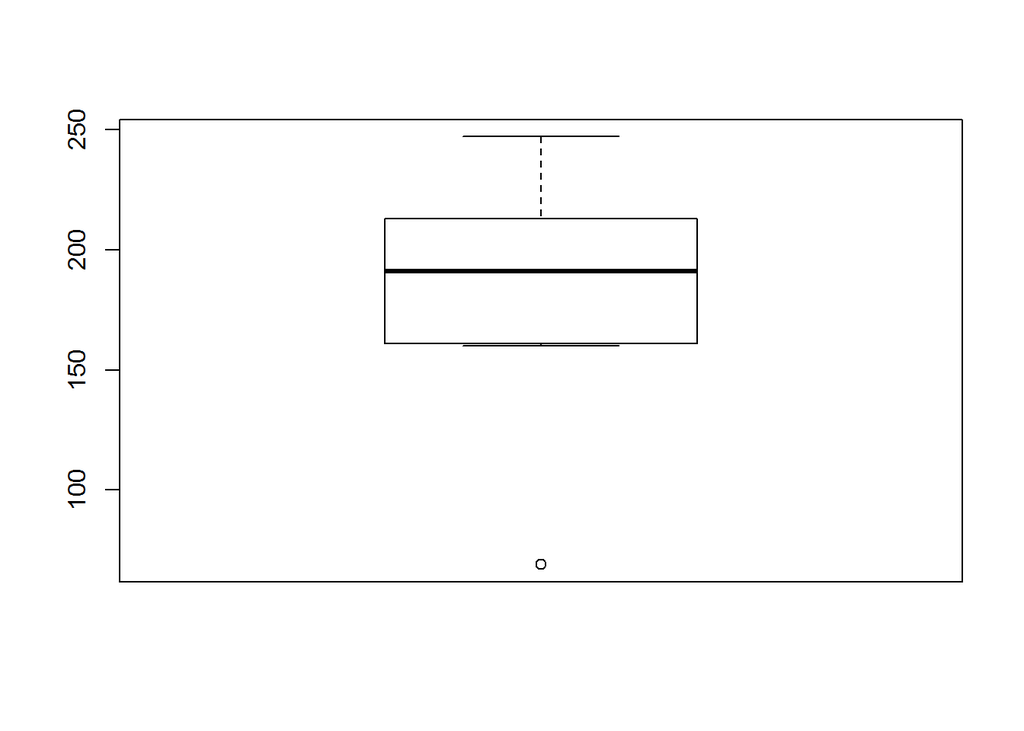

```r
boxplot(Player_new$AB)
```

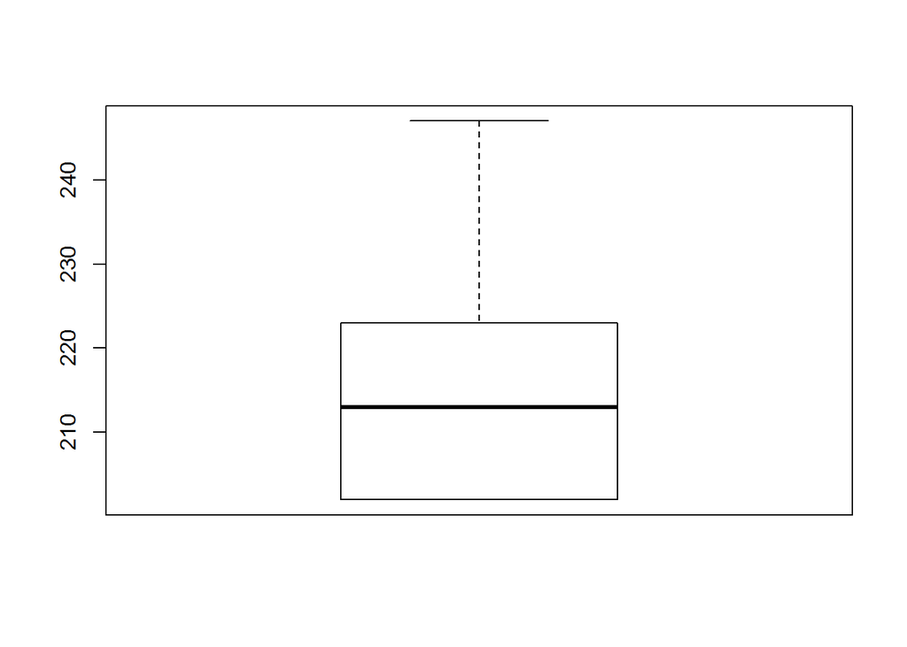

```r
Player_new$AB <- ifelse(Player_new$AB < 195.3, NA, Player_new$AB)

Player_new <- Player_new %>%
  filter(!is.na(AB))

boxplot(Player_new$AB)
```

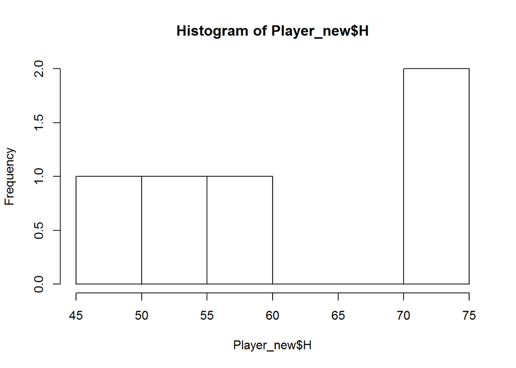

```r
hist(Player_new$H)
```

```r
reg1 <- lm(AVG ~ R, data=Team)
summary(reg1)
```

```
##
## Call:
## lm(formula = AVG ~ R, data = Team)
##
## Residuals:
##        Min         1Q     Median         3Q        Max
## -0.0203060 -0.0037942 -0.0001239  0.0034784  0.0172620
##
## Coefficients:
##              Estimate Std. Error t value Pr(>|t|)
## (Intercept) 1.977e-01  3.225e-03   61.30   <2e-16 ***
## R           1.136e-04  4.848e-06   23.44   <2e-16 ***
## ---
## Signif. codes:  0 '***' 0.001 '**' 0.01 '*' 0.05 '.' 0.1 ' ' 1
##
## Residual standard error: 0.006764 on 152 degrees of freedom
## Multiple R-squared:  0.7833, Adjusted R-squared:  0.7819
## F-statistic: 549.6 on 1 and 152 DF,  p-value: < 2.2e-16
```

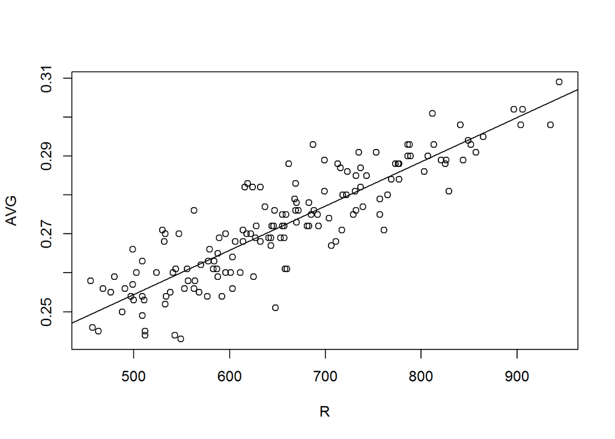

```r
with(Team, plot(AVG~R))
abline(reg1)
```

```r
reg0 <- lm(PO ~ R, data=Team)
summary(reg0)
```

```
##
## Call:
## lm(formula = PO ~ R, data = Team)
##
## Residuals:
##     Min      1Q  Median      3Q     Max
## -356.51  -79.49   -8.11   77.86  252.36
##
## Coefficients:
##              Estimate Std. Error t value Pr(>|t|)
## (Intercept) 2.811e+03  5.649e+01   49.77   <2e-16 ***
## R           1.157e+00  8.492e-02   13.63   <2e-16 ***
## ---
## Signif. codes:  0 '***' 0.001 '**' 0.01 '*' 0.05 '.' 0.1 ' ' 1
##
## Residual standard error: 118.5 on 152 degrees of freedom
## Multiple R-squared:  0.5499, Adjusted R-squared:  0.5469
## F-statistic: 185.7 on 1 and 152 DF,  p-value: < 2.2e-16
```

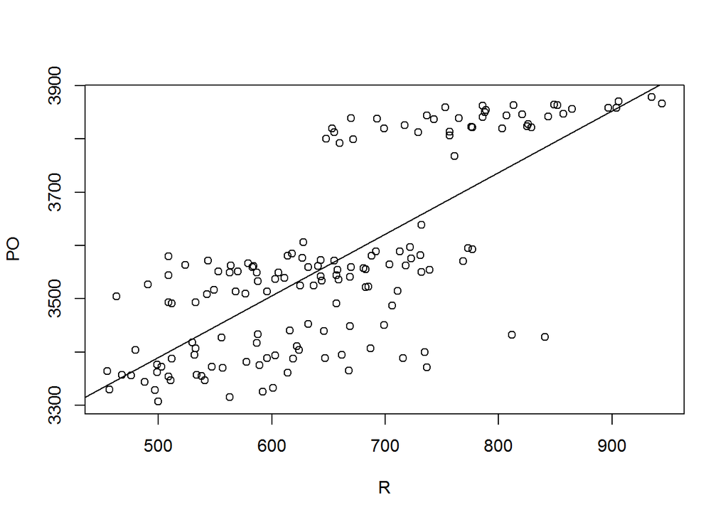

```r
with(Team, plot(PO~R))
abline(reg0)
```

```r
reg2 <- lm(OBP ~ R, data=Team)
summary(reg2)
```

```
##
## Call:
## lm(formula = OBP ~ R, data = Team)
##
## Residuals:
##        Min         1Q     Median         3Q        Max
## -0.0222980 -0.0053877 -0.0006741  0.0068626  0.0174377
##
## Coefficients:
##              Estimate Std. Error t value Pr(>|t|)
## (Intercept) 2.762e-01  4.364e-03   63.30   <2e-16 ***
## R           1.103e-04  6.560e-06   16.82   <2e-16 ***
## ---
## Signif. codes:  0 '***' 0.001 '**' 0.01 '*' 0.05 '.' 0.1 ' ' 1
##
## Residual standard error: 0.009154 on 152 degrees of freedom
## Multiple R-squared:  0.6504, Adjusted R-squared:  0.6481
## F-statistic: 282.8 on 1 and 152 DF,  p-value: < 2.2e-16
```

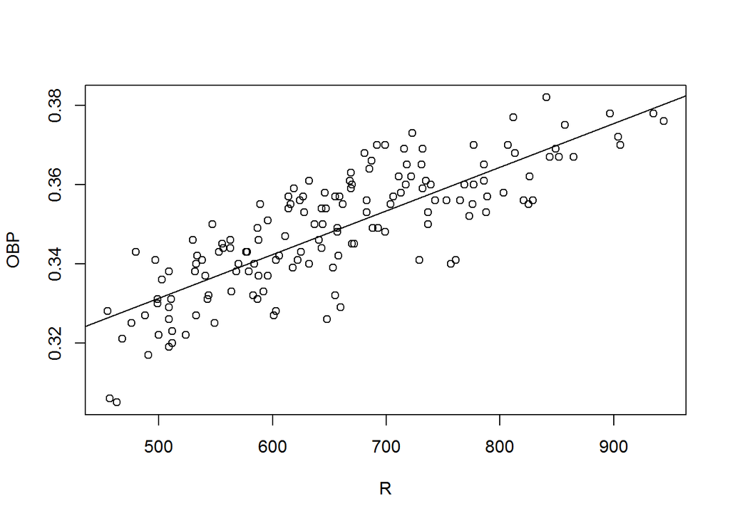

```r
with(Team, plot(OBP~R))
abline(reg2)
```

```r
reg3 <- lm(OPS ~ R, data=Team)
summary(reg3)
```

```
##
## Call:
## lm(formula = OPS ~ R, data = Team)
##
## Residuals:
##       Min        1Q    Median        3Q       Max
## -0.036074 -0.012919 -0.001539  0.011835  0.059486
##
## Coefficients:
##              Estimate Std. Error t value Pr(>|t|)
## (Intercept) 4.941e-01  8.481e-03   58.26   <2e-16 ***
## R           4.013e-04  1.275e-05   31.47   <2e-16 ***
## ---
## Signif. codes:  0 '***' 0.001 '**' 0.01 '*' 0.05 '.' 0.1 ' ' 1
##
## Residual standard error: 0.01779 on 152 degrees of freedom
## Multiple R-squared:  0.867,  Adjusted R-squared:  0.8661
## F-statistic: 990.5 on 1 and 152 DF,  p-value: < 2.2e-16
```

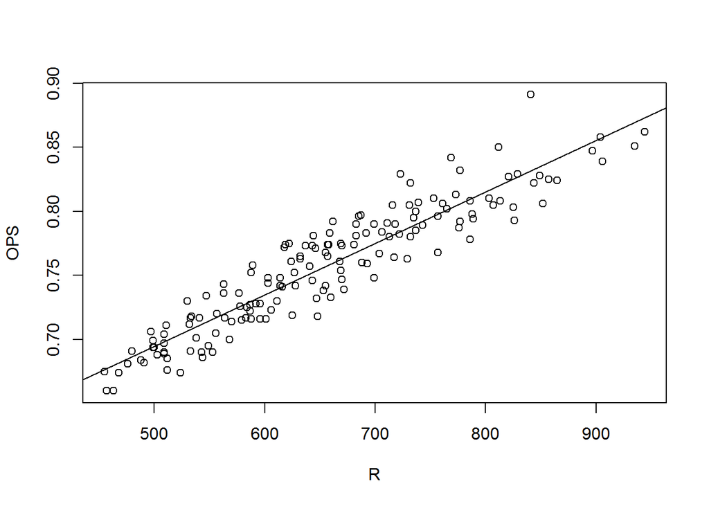

```r
with(Team, plot(OPS~R))
abline(reg3)
```

```r
reg4 <- lm(RC ~ R, data=Team)
summary(reg4)
```

```
##
## Call:
## lm(formula = RC ~ R, data = Team)
##
## Residuals:
##      Min       1Q   Median       3Q      Max
## -243.568  -40.306   -3.448   42.632  169.508
##
## Coefficients:
##              Estimate Std. Error t value Pr(>|t|)
## (Intercept) 833.69776   32.31129   25.80   <2e-16 ***
## R             1.65186    0.04857   34.01   <2e-16 ***
## ---
## Signif. codes:  0 '***' 0.001 '**' 0.01 '*' 0.05 '.' 0.1 ' ' 1
##
## Residual standard error: 67.78 on 152 degrees of freedom
## Multiple R-squared:  0.8838, Adjusted R-squared:  0.8831
## F-statistic:  1157 on 1 and 152 DF,  p-value: < 2.2e-16
```

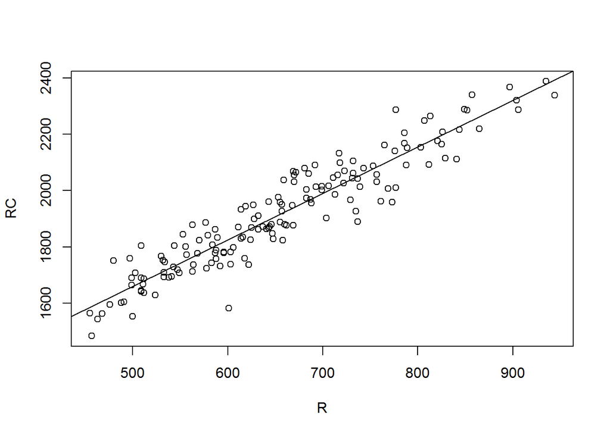

```r
with(Team, plot(RC~R))
abline(reg4)
```

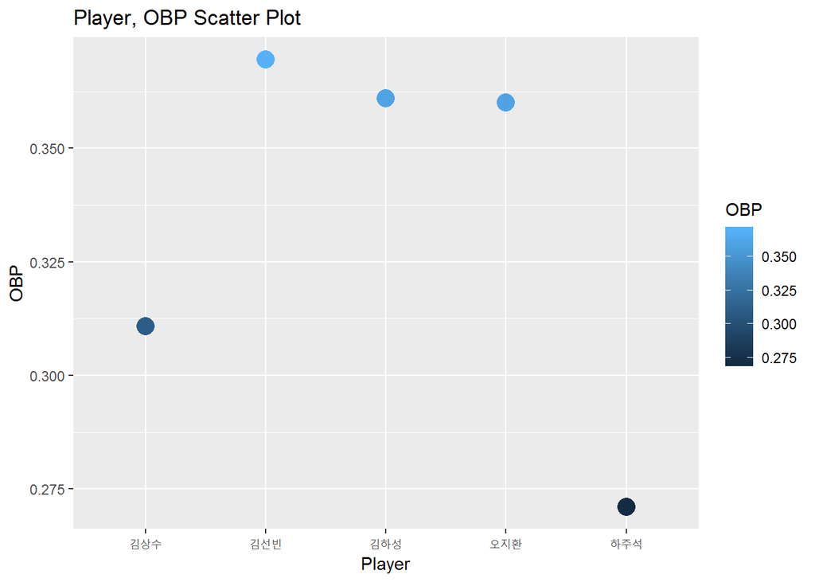

```r
y <- ggplot(data = Player_new, aes(Player, OBP, col=OBP)) +
  geom_point(size=5)
y + labs(title='Player, OBP Scatter Plot')
```

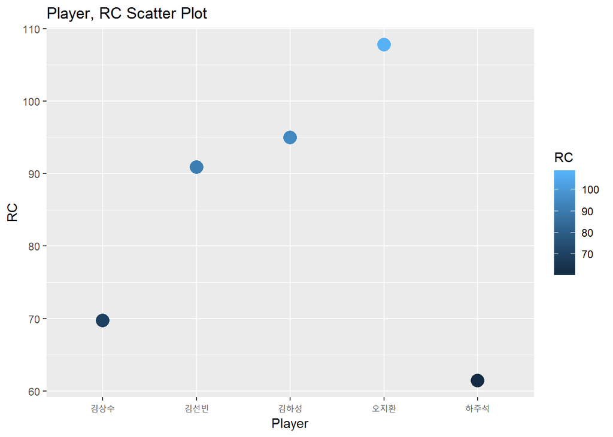

```r
x <- ggplot(data = Player_new, aes(Player, RC, col=RC)) +
         geom_point(size=5)
x + labs(title='Player, RC Scatter Plot')
```